# 세미나(2)

SeoHyeong Jeong

2018/01/11

*Source file* ⇒ 세미나_2_.Rmd

## 학습목표

1. Intro to Graphics
2. Components of Graphics
3. `ggplot2`(1)
4. `dplyr`(1) - Data Verbs
5. base package vs. `ggplot2`
- reference: UC Berkeley Stat 133 Data Computing By [Adam Lucas](http://rpubs.com/alucas)

## 1. Intro to Graphics

이번 세션에서는 다음의 패키지를 사용할 것이다: `mosaicData`.

```r
install.packages("mosaicData")
```

#### data()를 사용하여 R로 데이터를 로딩하기

data() 함수는 특정한 데이터셋을 특정 패키지로 부터 불러올 때 사용된다. 예를들어, `mosaicData` 패키지의 `CPS85`(1985 Current Population Survey) 데이터셋은 다음과 같이 불러올 수 있다.

| wage | educ | race | sex | hispanic | south | married | exper | union | age | sector |
| --- | --- | --- | --- | --- | --- | --- | --- | --- | --- | --- |
| 9.0 | 10 | W | M | NH | NS | Married | 27 | Not | 43 | const |
| 5.5 | 12 | W | M | NH | NS | Married | 20 | Not | 38 | sales |
| 3.8 | 12 | W | F | NH | NS | Single | 4 | Not | 22 | sales |
| 10.5 | 12 | W | F | NH | NS | Married | 29 | Not | 47 | clerical |
| 15.0 | 12 | W | M | NH | NS | Married | 40 | Union | 58 | const |
| 9.0 | 16 | W | F | NH | NS | Married | 27 | Not | 49 | clerical |

`mosaicData`는 여러 데이터셋을 포함하고 있으며 한번 로딩되면 (i.e. `library(mosaicData)`) 이 패키지에 포함된 모든 데이터셋을 컴퓨터의 메모리에 저장하게 된다. 따라서 모든 데이터셋이 아닌 특정 데이터셋만이 필요할 때, data()가 유용하게 사용된다.

```r
data("CPS85",package="mosaicData")
```

위의 명령은 `CPS85` 데이터셋만 로딩한다.

#### 기본 formula in R

R에서의 *formula*는 `~`을 이용하여 변수들 사이의 관계를 나타내게 해준다. y~x는 x로 표현된 y라는 함수라는 뜻을 가지고 있듯, wage ~ age라는 formula는 age를 독립변수(independent variable)로 wage를 종속변수(dependent variable)로 취급한다.

## 2. Components of Graphics

ggplot2 패키지에서 사용되는 graphic의 요소들을 살펴보자.

#### Glyphs and Data

Glyph 그 어원이 상형문자에서 온다.

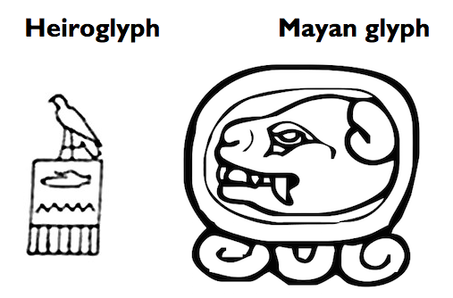

#### Data Glyphs (Geoms)

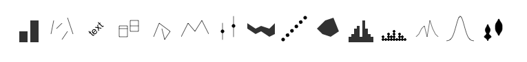

data glyph는 시각적으로 데이터를 표현하는 것이다.

- 어떤 것은 매우 간단한 형태이며, (예시: dots)
- 어떤 것은 데이터를 모아 요약한 형태이며, (예시: 히스토그램)
- 어떤 것은 데이터를 복잡한 형태로 표현한 것이다. (예시: confidence interval for expected conditional mean)

See: *http://docs.ggplot2.org/current/*

#### ggplot2 패키지로 만들어지는 그래프들의 구성요소:

`mosaicData::CPS85` 데이터 셋을 사용하여 살펴보자.

```r
data(CPS85, package="mosaicData")
head(CPS85)
```

| wage | educ | race | sex | hispanic | south | married | exper | union | age | sector |
| --- | --- | --- | --- | --- | --- | --- | --- | --- | --- | --- |
| 9.0 | 10 | W | M | NH | NS | Married | 27 | Not | 43 | const |
| 5.5 | 12 | W | M | NH | NS | Married | 20 | Not | 38 | sales |
| 3.8 | 12 | W | F | NH | NS | Single | 4 | Not | 22 | sales |
| 10.5 | 12 | W | F | NH | NS | Married | 29 | Not | 47 | clerical |
| 15.0 | 12 | W | M | NH | NS | Married | 40 | Union | 58 | const |
| 9.0 | 16 | W | F | NH | NS | Married | 27 | Not | 49 | clerical |

**Frame**= glyps가 그려질 사각형의 공간.

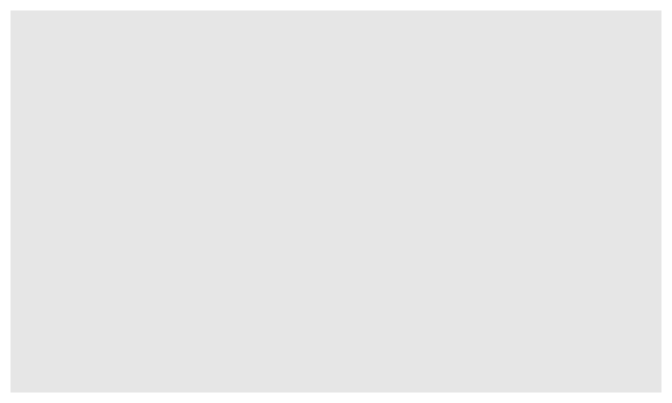

```r
ggplot()
```

**Aesthetics**= 데이터 테이블의 변수들과 관련있는 frame이나 glyphs의 특징들을 일컫는다. 예를들어, 색상, 모양, 그리고 점들의 위치가 aesthetics이다.

**Scales**= Scales은 데이터 테이블의 변수와 aesthetics 간의 mapping을 control한다.

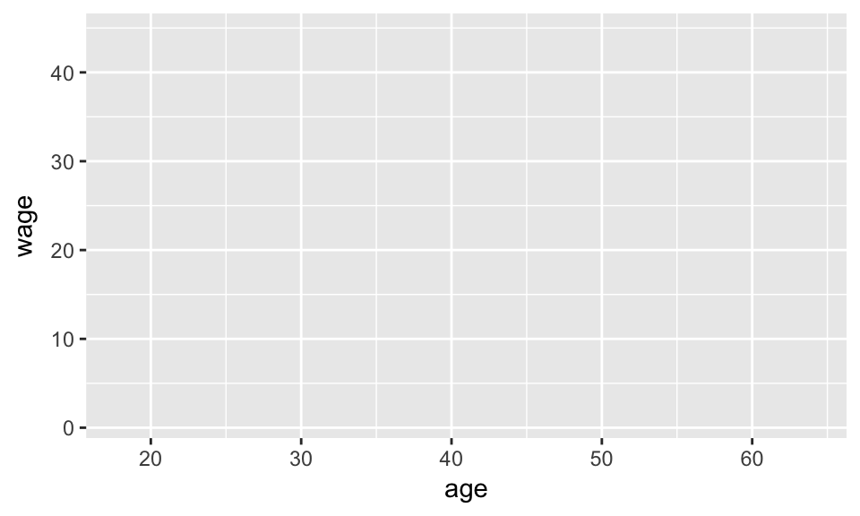

```r
CPS85 %>% ggplot(aes(x=age,y=wage))
```

**Glyph**= frame 속의 geometrical objects.

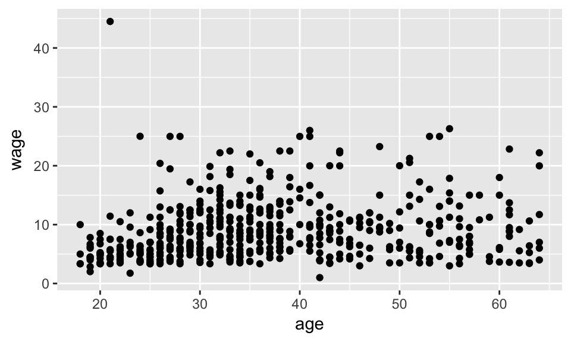

```r
CPS85 %>% ggplot(aes(x=age,y=wage)) + geom_point()
```

**Graphical Attributes**= glyphs의 특징 중 데이터 테이블의 변수들과 관련없는 것들을 일컫는다. 예를들어 투명도(alpha)라던지 색(for this case, color that applies to every point)가 그 예시이다.

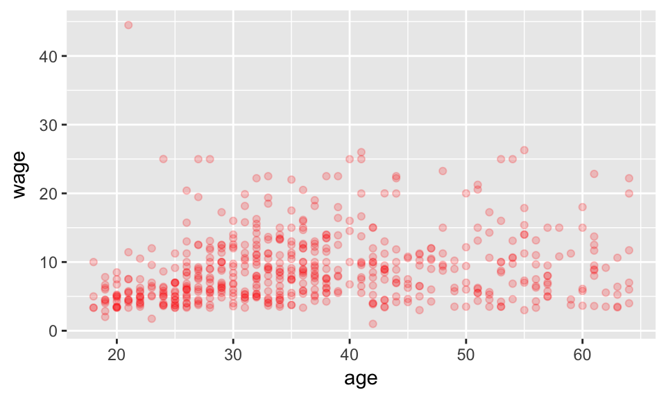

```r
CPS85 %>% ggplot(aes(x=age,y=wage)) + geom_point(alpha=.2, colour="red")
```

**Facets**= 카테고리 변수의 level을 나타내기 위해 여러개의 면으로 되어있는 display를 facet이라 한다.

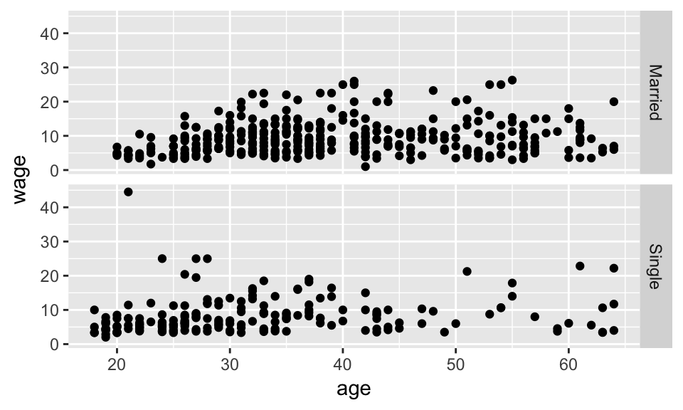

```r
CPS85 %>% ggplot(aes(x=age,y=wage)) + geom_point() + facet_grid(married ~ .)
```

**guides**= 보는 사람들에게 해당 그래프에서 scale(mapping)이 무엇인지 알 수 있도록 해주는 것.

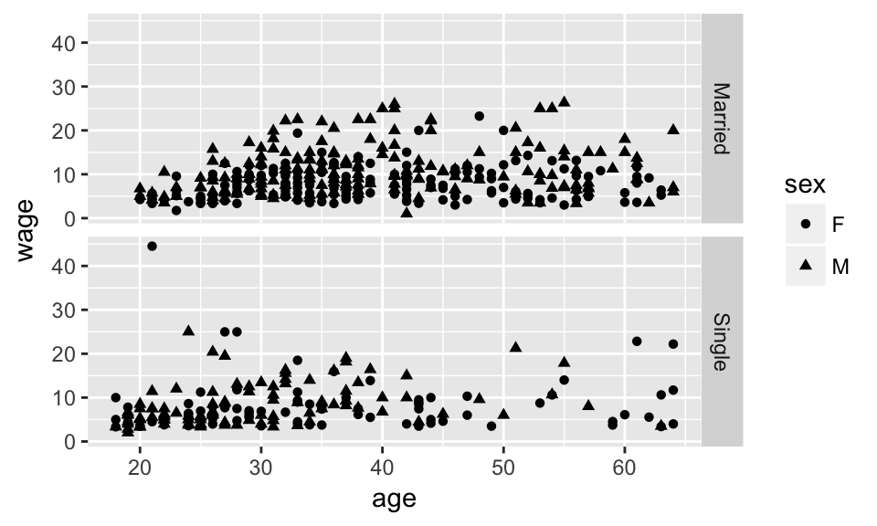

```r
CPS85 %>% ggplot(aes(x=age,y=wage)) + geom_point(aes(shape=sex)) + facet_grid(married ~ .)
```

guides의 예시:

- 축과 숫자

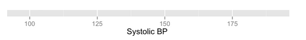

- Legends

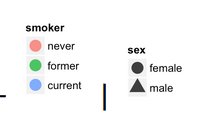

- faceted graphics의 labels

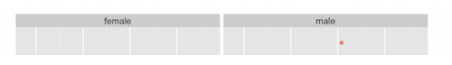

**Layers**= 두 개 이상의 glyph가 한 그래프에 있는 것을 layer가 있다고 한다.

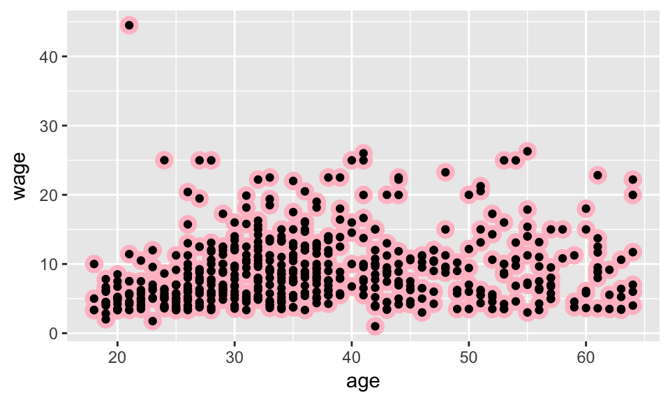

```r
CPS85 %>% ggplot(aes(x=age,y=wage)) +geom_point(colour = "pink", size = 4) + geom_point(colour = "black", size = 1.5)
```

#### 예시:

`mosaic::NHANES`데이터의 일부와 그에 해당하는 그래픽 표현이다.

sex

smoker

129

75

male

never

105

62

female

never

122

72

male

never

128

83

female

former

123

90

male

former

122

77

male

current

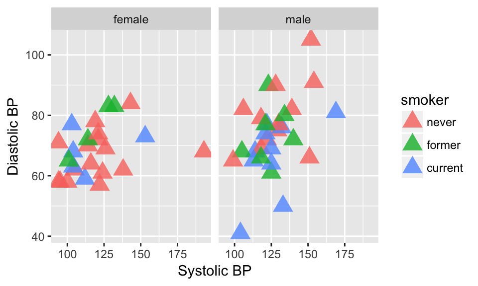

구성요소들은:

**Frame:** rectangular region

**Glyph:** points

**Facets:** sex

**Aesthetics:** The frames aesthetics is x and y. The points aesthetic is smoker.

**Scales:** x=sbp, y=dbp, color=smoker

**Graphical attributes:** size, alpha, shape

**Guides:** tick mark on axes, labels on faceted graphs, legend

**Layers:** none

ggplot2에서의 명령은 다음과 같다:

```r
p <- ggplot(df, aes(x = sbp, y = dbp)) +
  xlab("Systolic BP") + ylab("Diastolic BP")
p + geom_point(size=5, aes(color=smoker), alpha=.8, shape=17) +facet_grid(. ~ sex)
```

### Discuss

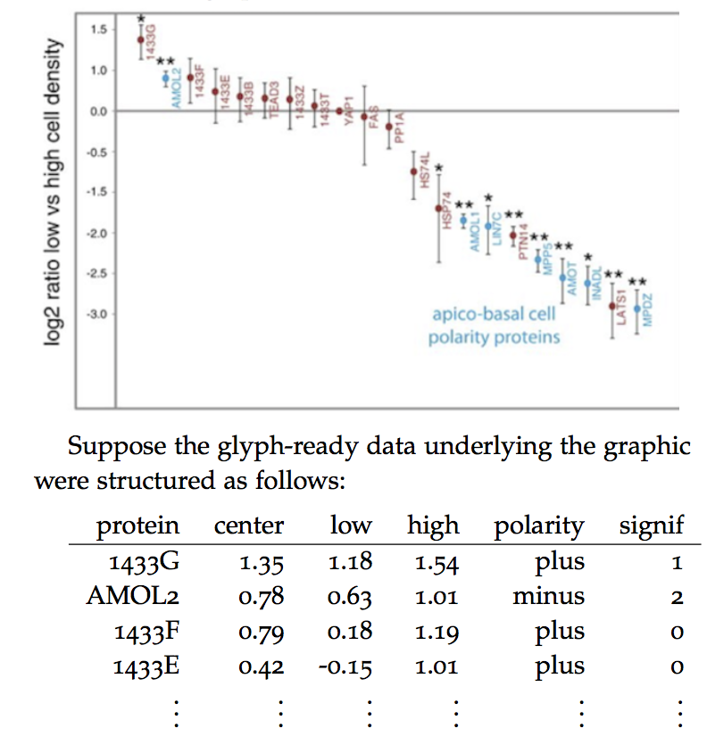

각각의 구성요소를 생각해보자:

*Frame:*

*Glyphs:*

*Facets:*

*Aesthetics:*

*Scales:*

*Graphical attributes:*

*Guides:*

*Layers:*

다음의 그래프는 [nytimes](http://www.nytimes.com/newsgraphics/2014/senate-model/comparisons.html) 에서 추출한 것이다. (prediction of 36 senate seats from different polling organizations)

[figure not shown]

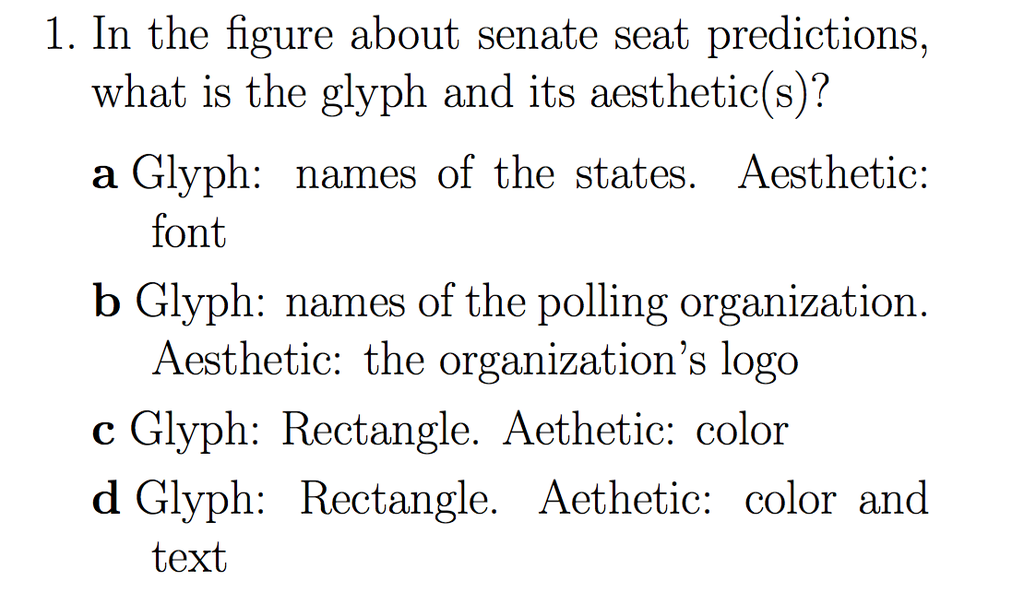

## 3. `ggplot2`(1)

`ggplot2` 패키지는 앞서 살펴본 그래프의 요소 (i.e. glyphs, aestetics, frames, scales, layers)를 사용한다. 이러한 요소들을 우리는 그래프의 문법이라 한다. 지금부터는 glyphs를 geoms으로 부르기로 한다.

### examples

다음은 mosaicData::CPS85 데이터 셋이다:

```r
data(CPS85,package="mosaicData")
head(CPS85)
```

| wage | educ | race | sex | hispanic | south | married | exper | union | age | sector |
| --- | --- | --- | --- | --- | --- | --- | --- | --- | --- | --- |
| 9.0 | 10 | W | M | NH | NS | Married | 27 | Not | 43 | const |
| 5.5 | 12 | W | M | NH | NS | Married | 20 | Not | 38 | sales |
| 3.8 | 12 | W | F | NH | NS | Single | 4 | Not | 22 | sales |
| 10.5 | 12 | W | F | NH | NS | Married | 29 | Not | 47 | clerical |
| 15.0 | 12 | W | M | NH | NS | Married | 40 | Union | 58 | const |
| 9.0 | 16 | W | F | NH | NS | Married | 27 | Not | 49 | clerical |

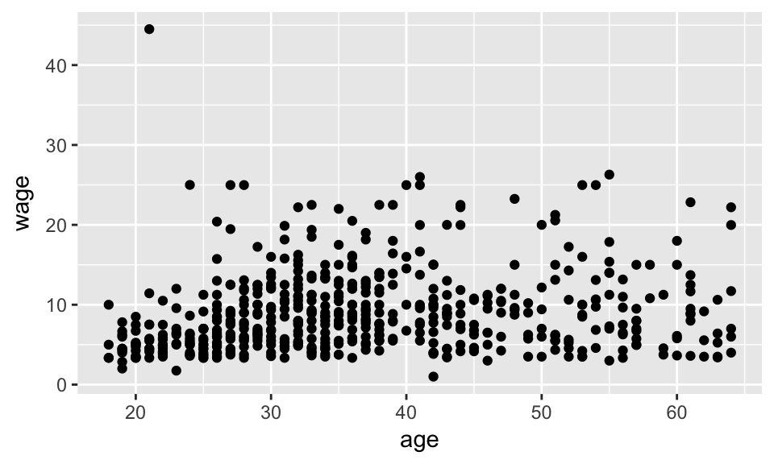

```r
frame <- CPS85 %>% ggplot(aes(x=age,y=wage))
frame + geom_point()
```

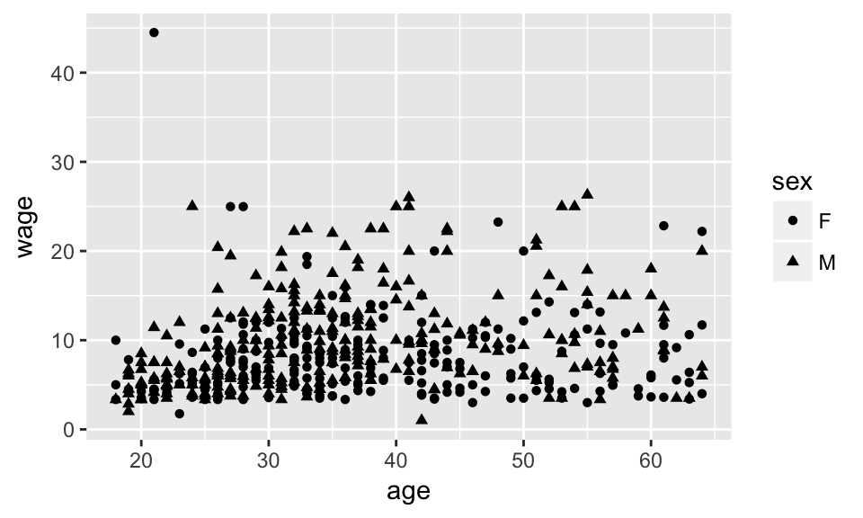

```r
frame <- CPS85 %>% ggplot(aes(x=age,y=wage))
frame + geom_point(aes(shape=sex))
```

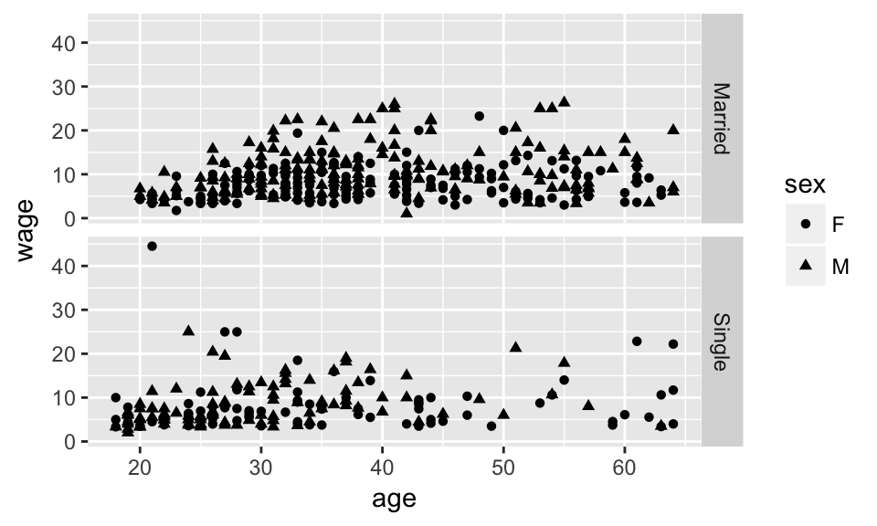

```r
frame <- CPS85 %>% ggplot(aes(x=age,y=wage))
frame + geom_point(aes(shape=sex)) + facet_grid(married ~ .)
```

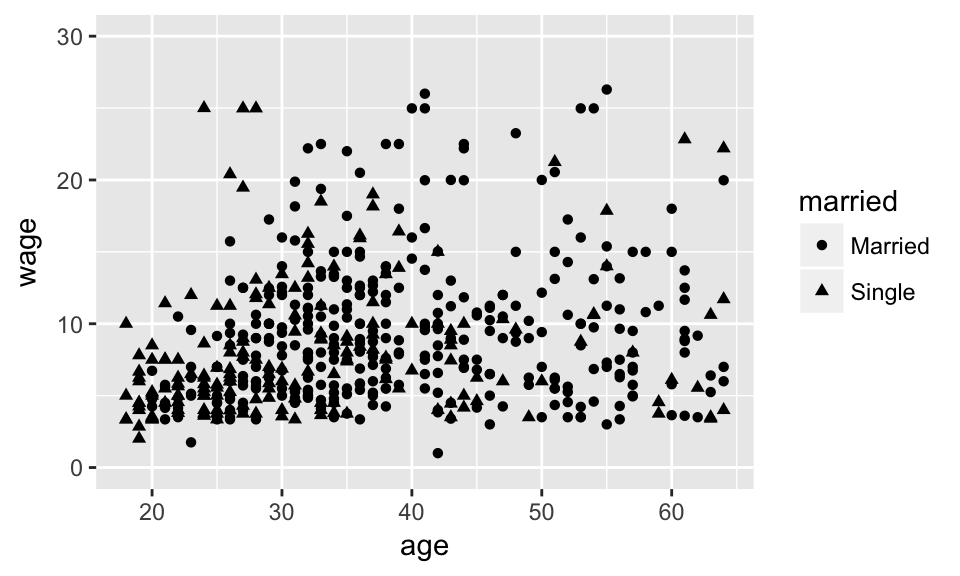

```r
frame <- CPS85 %>% ggplot(aes(x=age,y=wage))
frame + geom_point(aes(shape=married)) + ylim(0,30)
```

ggplot2와 관련된 자료는 다음의 링크를 통해 얻을 수 있다:

[ggplot](http://docs.ggplot2.org/current/)

[Rstudio](https://www.rstudio.com/wp-content/uploads/2015/03/ggplot2-cheatsheet.pdf)

### Discuss

`CPS85`을 이용하여 다음을 만들어라.

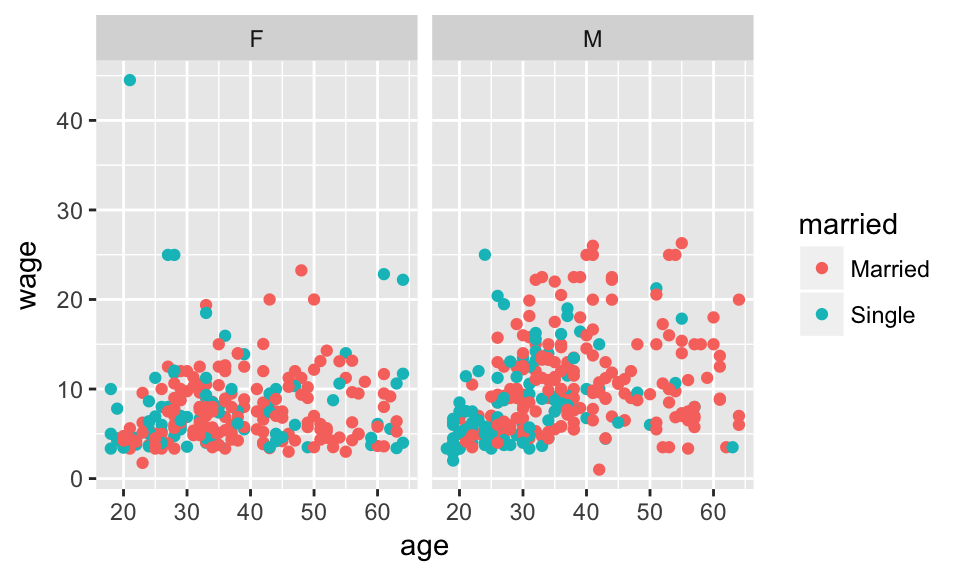

## 4. Data Verbs

데이터 테이블은 *glyph ready*(가공없이 ggplot2를 이용하여 그래프로 표현할 수 있는 상태)의 상태로 존재하기가 드물다. 따라서 데이터를 조작하는 것이 필요한데, 이러한 과정을 *wrangling*이라 한다. data verb는 데이터 테이블을 input으로 원하는 데이터 테이블을 output으로 반환하는 함수이다.

- `summarise()` and `group_by()`
- `select()`
- `mutate()`
- `filter()`
- `arrange()`

### 1) `summarise()` and `group_by()`

`summarise()` 와 `group_by()`는 가장 흔하게 쓰이는 data verb이다:

`summarise()` 은 `n()` or `sum()` or `mean()`등의 reduction formulas를 이용하여 여러개의 case를 하나의 case로 반환하는 함수이다.

예를들어:

```r
head(DataComputing::BabyNames)
```

| name | sex | count | year |
| --- | --- | --- | --- |
| Mary | F | 7065 | 1880 |
| Anna | F | 2604 | 1880 |
| Emma | F | 2003 | 1880 |
| Elizabeth | F | 1939 | 1880 |
| Minnie | F | 1746 | 1880 |
| Margaret | F | 1578 | 1880 |

```r
BabyNames %>% summarise(num_cases=n())  #gives the number of rows.
```

| num_cases |
| --- |
| 1792091 |

여기서 `n()`은 `summarise()` 내에서만 작동하는 reduction fuction이다.

`summarise(num_cases= n())`를 사용하는 대신, `nrow()` 혹은 `tally()` 함수 또한 동일하게 사용가능하다.

```r
BabyNames %>% nrow()
```

```
## [1] 1792091
```

```r
BabyNames %>% tally()
```

| n |
| --- |
| 1792091 |

`tally()`의 경우는 output이 데이터 테이블이라는 점에서 data verb에 해당하지만, `nrow()`는 그 output이 integer이기 때문에 data verb에 해당하지 않는다.

```r
BabyNames %>% summarise(average=mean(count)) #gives the average of counts
```

| average |
| --- |
| 186.0496 |

`mean()` 혹은 `sum()`는 *reduction* functions으로 변수를(ex. `count`)를 함수의 argument로 받는다.

만약 이름에 따른 요약 자료를 output 데이터 테이블로 얻고 싶다면 `group_by()` 와 `summarise()`를 함께 사용할 수 있다.

```r
BabyNames %>%
  group_by(name) %>%
  summarise(num_cases=n()) %>%
  head()
```

| name | num_cases |
| --- | --- |
| Aaban | 6 |
| Aabha | 2 |
| Aabid | 1 |
| Aabriella | 1 |
| Aadam | 22 |
| Aadan | 8 |

만약 `name`을 `sex`라는 하위그룹에 따라 나누고 싶다면,`group_by()` 에 `name` 과 `sex` (순서 유의, 두 번째로 오는 것이 하위그룹에 해당) 두 개의 arguments를 준다.

```r
BabyNames %>%
  group_by(name, sex) %>%
  summarise(num_cases=n(), sum_cases=sum(count))
```

```
## # A tibble: 102,690 x 4
## # Groups:   name [?]
##         name   sex num_cases sum_cases
##        <chr> <chr>     <int>     <int>
##  1     Aaban     M         6        56
##  2     Aabha     F         2        12
##  3     Aabid     M         1         5
##  4 Aabriella     F         1         5
##  5     Aadam     M        22       177
##  6     Aadan     M         8       104
##  7   Aadarsh     M        13       140
##  8     Aaden     F         1         5
##  9     Aaden     M        13      3677
## 10    Aadesh     M         3        15
## # ... with 102,680 more rows
```

BabyNames에서 가장 유명한 3개의 이름은?

```r
BabyNames %>%
  group_by(name) %>%
  summarise(tot=sum(count)) %>%
  arrange(desc(tot)) %>%
  head(3)
```

| name | tot |
| --- | --- |
| James | 5114325 |
| John | 5095590 |
| Robert | 4809858 |

### Discuss

1. 각 후보자들이 몇 개의 precints에서 first place를 얻었는지에 대한 bar plot을 만드려고 한다. 다음의 데이터를 data verb를 사용하여 glyph ready로 만들어보자.

```r
#not glyph ready
head(DataComputing::Minneapolis2013)
```

| Precinct | First | Second | Third | Ward |
| --- | --- | --- | --- | --- |
| P-10 | BETSY HODGES | undervote | undervote | W-7 |
| P-06 | BOB FINE | MARK ANDREW | undervote | W-10 |
| P-09 | KURTIS W. HANNA | BOB FINE | MIKE GOULD | W-10 |
| P-05 | BETSY HODGES | DON SAMUELS | undervote | W-13 |
| P-01 | DON SAMUELS | undervote | undervote | W-5 |
| P-04 | undervote | undervote | undervote | W-6 |

즉, 우리가 원하는 데이터의 형태는 아래와 같은 것이다.

```r
#glyph ready
FirstPlaceTally
```

| candidate | total |
| --- | --- |
| BETSY HODGES | 28935 |
| MARK ANDREW | 19584 |
| DON SAMUELS | 8335 |
| CAM WINTON | 7511 |
| JACKIE CHERRYHOMES | 3524 |
| BOB FINE | 2094 |
| DAN COHEN | 1798 |
| STEPHANIE WOODRUFF | 1010 |
| MARK V ANDERSON | 975 |
| undervote | 834 |
| DOUG MANN | 779 |
| OLE SAVIOR | 693 |
| ALICIA K. BENNETT | 351 |
| JAMES EVERETT | 347 |
| ABDUL M RAHAMAN “THE ROCK” | 338 |
| CAPTAIN JACK SPARROW | 264 |
| TONY LANE | 219 |
| MIKE GOULD | 204 |
| KURTIS W. HANNA | 200 |
| JAYMIE KELLY | 196 |
| CHRISTOPHER CLARK | 188 |
| CHRISTOPHER ROBIN ZIMMERMAN | 170 |
| JEFFREY ALAN WAGNER | 164 |
| TROY BENJEGERDES | 148 |
| NEAL BAXTER | 145 |
| GREGG A. IVERSON | 144 |
| UWI | 117 |
| JOSHUA REA | 108 |
| MERRILL ANDERSON | 108 |
| BILL KAHN | 97 |
| JOHN LESLIE HARTWIG | 97 |
| overvote | 93 |
| EDMUND BERNARD BRUYERE | 70 |
| RAHN V. WORKCUFF | 65 |
| JAMES “JIMMY” L. STROUD, JR. | 64 |
| BOB “AGAIN” CARNEY JR | 56 |
| CYD GORMAN | 39 |
| JOHN CHARLES WILSON | 37 |

2. 가장 ballots cast가 높은 precint에서 낮은 precint 순으로 데이터를 재정렬하려 하는 경우.

```r
Minneapolis2013 %>%
  group_by(Precinct) %>%
  summarise(count=n()) %>%     # n() finds how many cases there are
  arrange(desc(count))
```

| Precinct | count |
| --- | --- |
| P-06 | 9711 |
| P-02 | 9551 |
| P-08 | 9430 |
| P-03 | 8703 |
| P-05 | 8490 |
| P-07 | 8104 |
| P-04 | 7753 |
| P-01 | 7301 |
| P-09 | 5342 |
| P-10 | 1561 |
| P-04D | 852 |
| P-02D | 822 |
| P-05A | 742 |
| P-03A | 730 |
| P-01C | 505 |
| P-6C | 504 |

```r
#or


Minneapolis2013 %>%
  group_by(Precinct) %>%
  tally(sort=TRUE)
```

| Precinct | n |
| --- | --- |
| P-06 | 9711 |
| P-02 | 9551 |
| P-08 | 9430 |
| P-03 | 8703 |
| P-05 | 8490 |
| P-07 | 8104 |
| P-04 | 7753 |
| P-01 | 7301 |
| P-09 | 5342 |
| P-10 | 1561 |
| P-04D | 852 |
| P-02D | 822 |
| P-05A | 742 |
| P-03A | 730 |
| P-01C | 505 |
| P-6C | 504 |

3. 2번과 같이 precint를 정렬하되, “BETSY HODGES”를 first로 가지는 ballots cast를 기준으로 precint를 정렬하는 경우.

```r
Minneapolis2013 %>%
    filter(First =="BETSY HODGES") %>%
    group_by(Precinct) %>%
    tally(sort=TRUE)
```

| Precinct | n |
| --- | --- |
| P-06 | 3762 |
| P-02 | 3739 |
| P-08 | 3480 |
| P-07 | 3073 |
| P-05 | 2895 |
| P-01 | 2793 |
| P-03 | 2663 |
| P-04 | 2571 |
| P-09 | 1943 |
| P-10 | 486 |
| P-02D | 326 |
| P-04D | 319 |
| P-05A | 303 |
| P-03A | 295 |
| P-01C | 161 |
| P-6C | 126 |

4. 몇 개의 투표에서 “BETSY HODGES”가 First와 Second 모두 선택되었는지 알고 싶은 경우.

```r
Minneapolis2013 %>%
  filter(Second == "BETSY HODGES", First == "BETSY HODGES") %>%
  tally()   #could also use nrow here
```

| n |
| --- |
| 222 |

```r
Minneapolis2013 %>%
  group_by(First,Second) %>%
  tally() %>%
  filter(First=="BETSY HODGES", Second=="BETSY HODGES")
```

```
## # A tibble: 1 x 3
## # Groups:   First [1]
##          First       Second     n
##          <chr>        <chr> <int>
## 1 BETSY HODGES BETSY HODGES   222
```

### 2) `select()`

데이터 테이블에서 select 함수는 하나 혹은 그 이상의 변수를 선택하는데 사용된다. select 함수를 사용하는 이유는 다음과 같다:

- 작업 중인 데이터 테이블을 간단하게 하기 위해서
- 이름을 다시 붙여야 할 변수가 있는 경우 더욱 적합한 이름을 붙이기 위해서

select 함수는 데이터 테이블을 input으로 받아, 선택한 변수들만으로 이루어진 데이터 테이블을 반환한다.

`BabyNames` 데이터 테이블로 예시를 살펴보자:

| name | sex | count | year |
| --- | --- | --- | --- |
| Mary | F | 7065 | 1880 |
| Anna | F | 2604 | 1880 |
| Emma | F | 2003 | 1880 |
| Elizabeth | F | 1939 | 1880 |
| Minnie | F | 1746 | 1880 |
| Margaret | F | 1578 | 1880 |

`name`과 `year` 변수만을 선택하는 경우:

| name | year |
| --- | --- |
| Mary | 1880 |
| Anna | 1880 |
| Emma | 1880 |
| Elizabeth | 1880 |
| Minnie | 1880 |
| Margaret | 1880 |

변수에 새로운 이름을 붙이고 싶은 경우,`when=year`의 argument를 select 함수로 보낸다:

```r
BabyNames %>% select( name, when=year )
```

| name | when |
| --- | --- |
| Mary | 1880 |
| Anna | 1880 |
| Emma | 1880 |
| Elizabeth | 1880 |
| Minnie | 1880 |
| Margaret | 1880 |

### 3) `filter()`

“filter”은 원하지 않는 cases을 걸러내는데 사용된다. 앞서 살펴본 filter과는 반대의 개념을 가진다. select 함수의 경우 특정한 *변수*를 input으로 가지지만, filter 함수는 특정한 *case*를 input으로 가진다.

select에서는 함수의 input의 변수이 이름이다.

```r
BabyNames %>% select( year, count ) %>% head()
```

| year | count |
| --- | --- |
| 1880 | 7065 |
| 1880 | 2604 |
| 1880 | 2003 |
| 1880 | 1939 |
| 1880 | 1746 |
| 1880 | 1578 |

filter에서는 case가 특정 기준으로 인해 정해진다. 여기서 기준은 그 결과가 true/false로 도출되는 논리문을 의미한다. 즉, `==`, `>`, `<`, `%in%` 등의 표현으로 완성되는 논리문이다. 예를들어, 다음은 남아들을 걸러내고 오직 여야들의 이름만 결과로 도출하는 command이다.

```r
BabyNames %>% filter( sex=="F") %>%
  sample_n( size=6 )
```

|  | name | sex | count | year |
| --- | --- | --- | --- | --- |
| 505956 | Sintia | F | 5 | 1979 |
| 544977 | Iman | F | 48 | 1983 |
| 12108 | Zella | F | 108 | 1890 |
| 1061450 | Malanya | F | 5 | 2013 |
| 408178 | Pura | F | 7 | 1970 |
| 699230 | Dolly | F | 38 | 1994 |

다음은 1990년도 이후 태어난 아기들의 이름이다.

```r
BabyNames %>% filter( year > 1990 ) %>%
  sample_n( size=6 )
```

|  | name | sex | count | year |
| --- | --- | --- | --- | --- |
| 81527 | Corinthia | F | 19 | 1994 |
| 362438 | Cayleigh | F | 74 | 2004 |
| 371508 | Railynn | F | 9 | 2004 |
| 126598 | Khalique | M | 6 | 1995 |
| 161074 | Shacora | F | 16 | 1997 |
| 274132 | Porscha | F | 19 | 2001 |

1990년도 이후 테어난 아기들 중 여아:

```r
BabyNames %>% filter( year > 1990, sex=="F") %>%
  head()
```

[output not shown]

기준은 하나 이상이 될 수도 있다. `filter()` 함수는 기준이 하나 이상일 때, *모든* 기준을 만족시키는 case만을 골라낸다.

만약, “or”을 표현하고 싶다면(the babies who are female *or* born after 1990):

```r
BabyNames %>% filter( year>1990 | sex=="F")
```

1980, 1990, 2000, and 2010 중 하나에 태어난 아기들의 이름:

```r
BabyNames %>%
  filter( year %in% c(1980, 1990, 2000, 2010)) %>%
  sample_n( size=6 )
```

|  | name | sex | count | year |
| --- | --- | --- | --- | --- |
| 56355 | Fraida | F | 7 | 2000 |
| 14166 | Danyell | M | 27 | 1980 |
| 39850 | Ka | M | 10 | 1990 |
| 72041 | Tomias | M | 6 | 2000 |
| 30031 | Holliann | F | 7 | 1990 |
| 30848 | Adrine | F | 6 | 1990 |

`filter()` 와 `group_by()`를 함께 사용하면 원하는 결과를 효율적으로 얻을 수 있다. 예를들어, 이름 중 빈도수가 적어도 100 이상인 이름을 고르려면:

```r
BabyNames %>% group_by(name) %>%
  filter(count==min(count)) %>%
  filter(count>100) %>%
  head()
```

```
## # A tibble: 4 x 4
## # Groups:   name [4]
##       name   sex count  year
##      <chr> <chr> <int> <int>
## 1   Jessie     M   143  1881
## 2 Jacqueli     F   157  1989
## 3 Cassandr     F   152  1989
## 4 Christop     M  1082  1989
```

아기 이름 중 100년 넘게 사용된 것들만 고르고 싶다면:

```r
BabyNames %>% group_by(name) %>%
  summarise(years_used=n()) %>%
  filter(years_used>100) %>%
  head()
```

| name | years_used |
| --- | --- |
| Aaron | 218 |
| Abbie | 176 |
| Abby | 156 |
| Abe | 134 |
| Abel | 150 |
| Abigail | 169 |

### 4) `mutate()`

mutate 함수는 이미 존재하는 변수에 변형을 가하거나, 새로운 변수 (파생변수)를 만드는데 사용된다. mutate 함수의 사용은 case를 제거하지 않은채, 변수에 변형을 가할 뿐이다.

예를들어, `CountryData` 데이터 테이블이`pop` 과 `area` 라는 변수를 가지고 있다. 여기서 인구 밀도를 얻고 싶을 때, mutate를 이용하여 새로운 변수를 생성할 수 있다.

```r
  CountryData %>%
  mutate( popDensity=pop/area ) %>%
  select( country, pop, area, popDensity) %>%
  sample_n(size=6)
```

|  | country | pop | area | popDensity |
| --- | --- | --- | --- | --- |
| 106 | Howland Island | NA | 2 | NA |
| 235 | Turkmenistan | 5171943 | 488100 | 10.596073 |
| 92 | Greece | 10775557 | 131957 | 81.659609 |
| 218 | Suriname | 573311 | 163820 | 3.499640 |
| 126 | Korea, South | 49039986 | 99720 | 491.776835 |
| 28 | Bolivia | 10631486 | 1098581 | 9.677471 |

### 5) `arrange()`

Arrange 함수는 case들의 순서를 재정렬한다. 하지만 변수에 변형을 가하지는 않는다 — that’s a job for `mutate()`. 마찬가지로 arrange 함수 또한 특정 case를 걸러내지 않는다. 즉, case에 변형을 가하지 않는다. 단지 사용자가 지정하는 특정 기준에 따라 case를 정렬할 뿐이다.

예를들어, 아래는 투표 수를 계산(first-choices만 계산)하여 2013년 Minneapolis의 시장선거 결과를 나타낸 것이다.

```r
Minneapolis2013 %>%
  group_by( First ) %>%
  summarise( total=n() ) %>%
  head()
```

| First | total |
| --- | --- |
| ABDUL M RAHAMAN “THE ROCK” | 338 |
| ALICIA K. BENNETT | 351 |
| BETSY HODGES | 28935 |
| BILL KAHN | 97 |
| BOB “AGAIN” CARNEY JR | 56 |
| BOB FINE | 2094 |

위 결과를 보면 후보자 이름이 알파벳 순으로 정렬되어 있는 것을 알 수 있다. 하지만 사용자가 원하는 것이 후보자들 간의 `total` 수 비교라면 `total`을 내림차순으로 정렬하는 것이 더 효율적인 데이터 표현 방식일 수 있다.

```r
Minneapolis2013 %>%
  group_by( First ) %>%
  summarise( total=n() ) %>%
  arrange( desc(total) ) %>%
  head()
```

| First | total |
| --- | --- |
| BETSY HODGES | 28935 |
| MARK ANDREW | 19584 |
| DON SAMUELS | 8335 |
| CAM WINTON | 7511 |
| JACKIE CHERRYHOMES | 3524 |
| BOB FINE | 2094 |

### Data verb languages

우리가 사용하고 있는 것은 `dplyr`라는 패키지이다. 하지만 `dplyr`를 이용하여 data wrangling하는 것은 여러 방법들 중 하나일 뿐이라는 것을 인식하는 것이 중요하다. 예를 들면, 다른 여러 방법에는 다음과 같은 것들이 있다:

- dplyr - R에서 사용
- data.table - R에서 사용 (for big data)
- SQL - database servers에서 사용

같은 표현을 다른 notation으로 하면 다음과 같다:

- dplyr `BabyNames %>% group_by(year,sex) %>% summarise( nNames=n() )`
- data.table `BabyNames[, length(count), by=c("sex","year") ]`
- SQL `"BabyNames" > GROUP_BY("year", "sex") > SUMMARISE(COUNT() AS "nNames")`

## 5. base package vs. `ggplot2`

mtcars data set을 사용해보자.

```r
mtcars_m <- mtcars %>%
  filter(am==0)

mtcars_a <- mtcars %>%
  filter(am==1)

head(mtcars_a)
```

| mpg | cyl | disp | hp | drat | wt | qsec | vs | am | gear | carb |
| --- | --- | --- | --- | --- | --- | --- | --- | --- | --- | --- |
| 21.0 | 6 | 160.0 | 110 | 3.90 | 2.620 | 16.46 | 0 | 1 | 4 | 4 |
| 21.0 | 6 | 160.0 | 110 | 3.90 | 2.875 | 17.02 | 0 | 1 | 4 | 4 |
| 22.8 | 4 | 108.0 | 93 | 3.85 | 2.320 | 18.61 | 1 | 1 | 4 | 1 |
| 32.4 | 4 | 78.7 | 66 | 4.08 | 2.200 | 19.47 | 1 | 1 | 4 | 1 |
| 30.4 | 4 | 75.7 | 52 | 4.93 | 1.615 | 18.52 | 1 | 1 | 4 | 2 |
| 33.9 | 4 | 71.1 | 65 | 4.22 | 1.835 | 19.90 | 1 | 1 | 4 | 1 |

ggplot 패키지가 개발되기 전 R에서 graphing을 담당했던 것은 *base R package*이다. 아직도 많은 연구자들이 base package를 이용한 그래프로 작업하는 경우가 있으니 base package와 ggplot을 비교하며 그 차이점을 알아보자.

### 예시 1

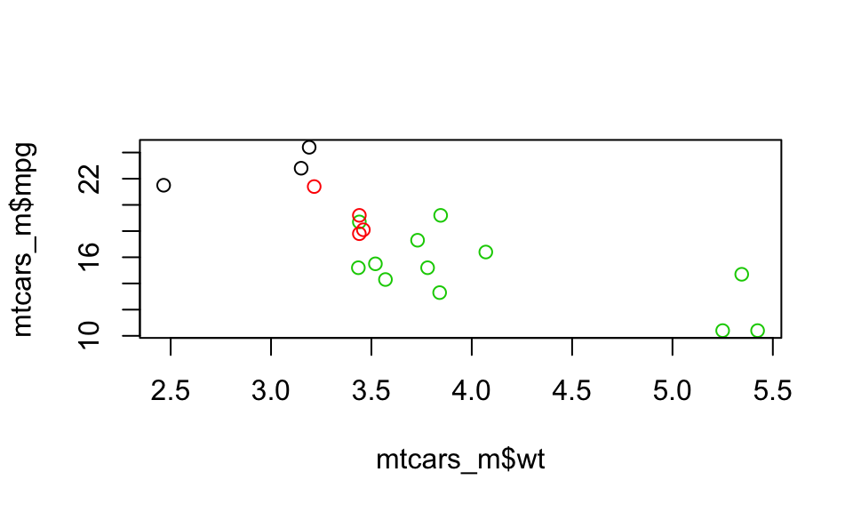

```r
plot( mtcars_m$wt,mtcars_m$mpg, col=as.factor(mtcars_m$cyl))
```

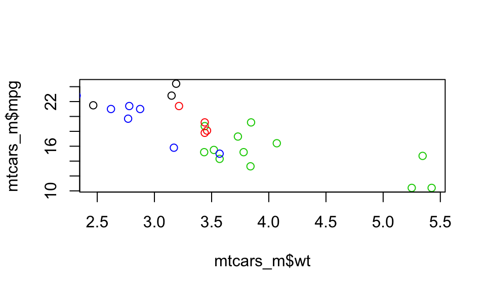

```r
plot(mtcars_m$wt,mtcars_m$mpg,  col=as.factor(mtcars_m$cyl))
points( mtcars_a$wt,mtcars_a$mpg, col="blue")
```

base package를 이용할 때의 한계점은:

1. 그래프가 다시 그려지지 않는다.
2. 그래프가 하나의 이미지로써 그려질 뿐이다. 즉, object로 표현되지 않는다. 하지만 ggplot에서는 그래프가 object로 표현된다. 따라서 원하는 변경사항이 있을 경우 손 쉽게 변경을 가할 수 있다.
3. legend이 필요한 경우 사용자가 직접 만들어야 한다. 예를들어, 위의 그래프에서 무슨 색이 어떤 정보를 주는지에 대한 legend이 필요한 경우 직접 만들어야 한다는 것이다.

ggplot을 이용하는 경우:

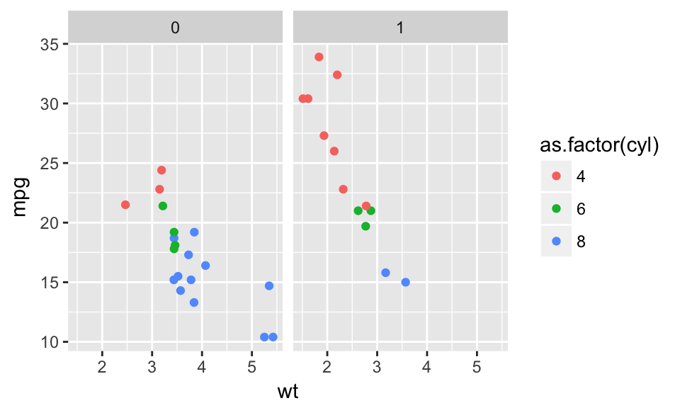

```r
mtcars %>% ggplot(aes(x=wt,y=mpg)) + geom_point(aes(col=as.factor(cyl))) + facet_wrap(~am)
```

### Discuss

벡터 `precip`는 여러 도시에서의 매년 강수량에 대한 정보를 담고 있다. bace package를 이용하여 `hist` 함수로 다음의 히스토그램을 만들어라(hint: try `hist(precip)`). 그리고 ggplot의`geom_histogram()` 함수를 사용하여 히스토그램을 만들어라. ggplot은 데이터 테이블를 input으로 받기 때문에 `as.data.frame(precip)` 과정이 필요할 것.

[ggplot2.org](http://docs.ggplot2.org/current/index.html)

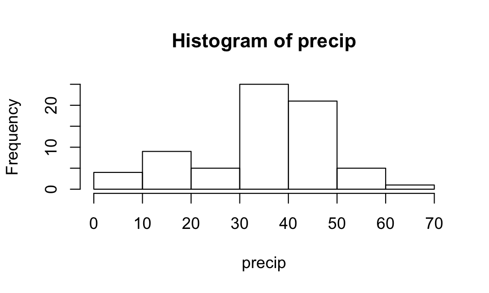

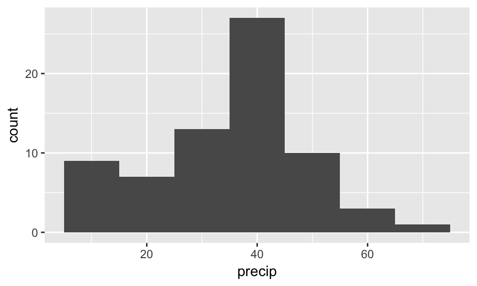

### 예시 2

mpg ~ wt(weight)의 linear model을 만들고 싶은 경우를 가정하자.

```r
# Use lm() to calculate a linear model and save it as carModel
carModel <- lm(mpg ~ wt, data = mtcars_m)
carModel
```

```
##
## Call:
## lm(formula = mpg ~ wt, data = mtcars_m)
##
## Coefficients:
## (Intercept)           wt
##      31.416       -3.786
```

위에서 base package로 그렸던 plot에 linear model과 legend를 추가해보자.

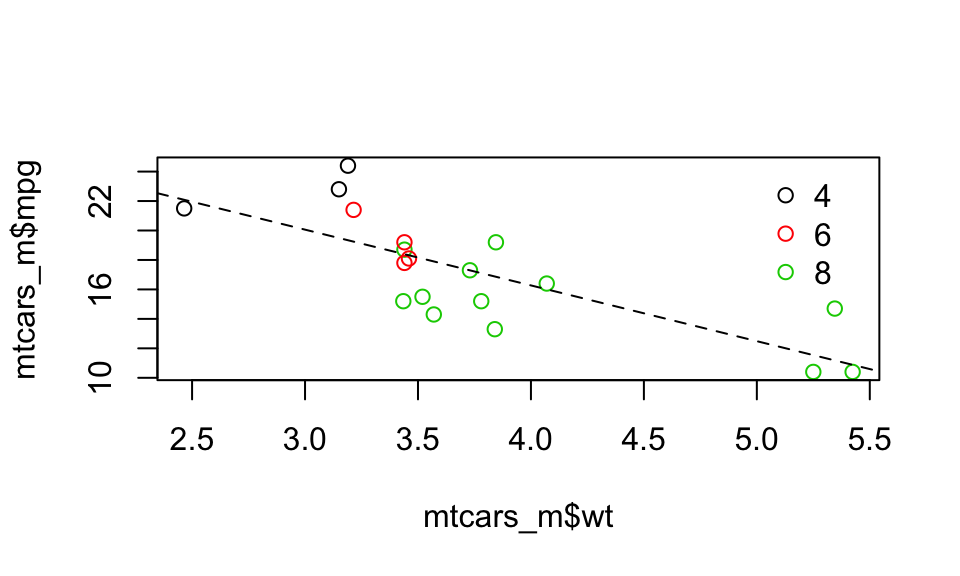

```r
plot(mtcars_m$wt,mtcars_m$mpg,  col=as.factor(mtcars_m$cyl))
carModel <- lm(mpg ~ wt, data = mtcars_m)
abline(carModel, lty = 2)
legend(x = 5, y = 25, legend = levels(as.factor(mtcars_m$cyl)), col = 1:3, pch = 1, bty = "n")
```

혹은 실린더의 타입에 따라 각각의 linear model을 설정하는 경우 plot은 다음과 같을 것이다.

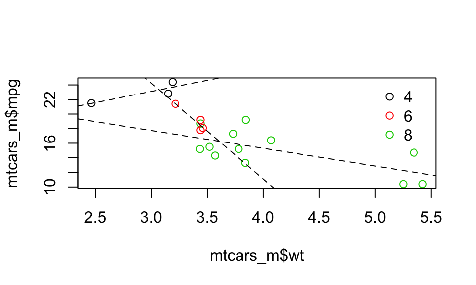

```r
plot(mtcars_m$wt,mtcars_m$mpg,  col=as.factor(mtcars_m$cyl))
abline(lm(mpg ~ wt, data = mtcars_m, subset= (cyl ==4)), lty = 2)
abline(lm(mpg ~ wt, data = mtcars_m, subset= (cyl ==6)), lty = 2)
abline(lm(mpg ~ wt, data = mtcars_m, subset= (cyl ==8)), lty = 2)
legend(x = 5, y = 25, legend = levels(as.factor(mtcars_m$cyl)), col = 1:3, pch = 1, bty = "n")
```

물론 `lapply()` 함수를 이용하여 좀 더 같단하게 그래프를 표현할 수도 있다.

```r
plot(mtcars_m$wt,mtcars_m$mpg,  col=as.factor(mtcars_m$cyl))
lapply(mtcars_m$cyl, function(x) {
  abline(lm(mpg ~ wt, mtcars_m, subset = (cyl == x)), col = x)
  })
legend(x = 5, y = 25, legend = levels(as.factor(mtcars_m$cyl)), col = 1:3, pch = 1, bty = "n")
```

[output not shown]

하지만 이 모든 것은 ggplot에서 매우 간단하게 처리할 수 있다.

**Note** color aesthetic을 geom_point에 위치시키는 대신, ggplot의 frame에 위치시킨 것을 볼 수 있는데, 이는 point와 regression line의 색을 일치시키기 위함이다. legend 또한 특별한 조작 없이 자동으로 완성되는 것을 볼 수 있다.

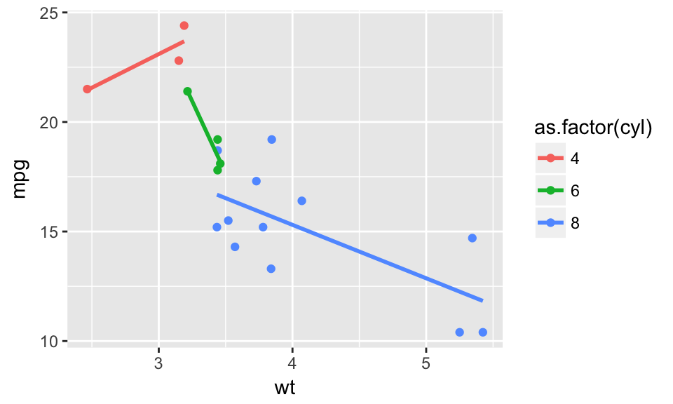

```r
mtcars_m %>% ggplot(aes(x = wt, y = mpg, col = as.factor(cyl))) +
  geom_point() +
  geom_smooth(method = "lm", se = FALSE)
```